# Princeton Winter Session 2022: Introduction to Data Analysis in R

# Data Types in R

## Vectors

```r
v1 = c(1,2,3,4,5)
v1
```

```
[1] 1 2 3 4 5
```

```r
v2 = c("a", "b", "c", c(3,2,1))
v2
```

```
[1] "a" "b" "c" "3" "2" "1"
```

## Environments in R

Listing objects for a given environment:

```r
ls()
```

```
 [1] "big_nums"         "cl"               "ctrl"             "cub.model"
 [5] "cursor"           "df"               "dupes"            "filter"
 [9] "future_times"     "future_values"    "glmnet.model"     "hex.model"
[13] "lin.model"        "logic1"           "logic2"           "max1"
[17] "max2"             "models"           "null.model"       "nums"
[21] "nums_product"     "pent.model"       "precip"           "probs"
[25] "probs.test.lasso" "probs.test.rf"    "probs.test.svm"   "probs.train.svm"
[29] "quad.model"       "resamps"          "resamps.diff"     "rf.model"
[33] "roc.lasso.test"   "roc.rf.test"      "roc.svm.test"     "roc.svm.train"
[37] "s"                "s2"               "samples"          "session_objects"
[41] "squares"          "svm.model"        "temp"             "test.data"
[45] "test.X"           "test.y"           "tetr.model"       "tIdx"
[49] "tox"              "train.data"       "train.X"          "train.y"
[53] "v1"               "v2"               "vitax"            "vitax.df"
[57] "x"                "y"
```

Removing objects from the environment:

```r
rm("v2")
ls()
```

```
 [1] "big_nums"         "cl"               "ctrl"             "cub.model"
 [5] "cursor"           "df"               "dupes"            "filter"
 [9] "future_times"     "future_values"    "glmnet.model"     "hex.model"
[13] "lin.model"        "logic1"           "logic2"           "max1"
[17] "max2"             "models"           "null.model"       "nums"
[21] "nums_product"     "pent.model"       "precip"           "probs"
[25] "probs.test.lasso" "probs.test.rf"    "probs.test.svm"   "probs.train.svm"
[29] "quad.model"       "resamps"          "resamps.diff"     "rf.model"
[33] "roc.lasso.test"   "roc.rf.test"      "roc.svm.test"     "roc.svm.train"
[37] "s"                "s2"               "samples"          "session_objects"
[41] "squares"          "svm.model"        "temp"             "test.data"
[45] "test.X"           "test.y"           "tetr.model"       "tIdx"
[49] "tox"              "train.data"       "train.X"          "train.y"
[53] "v1"               "vitax"            "vitax.df"         "x"
[57] "y"
```

## Variables

Variables require an assignment operator:

```r
x=10
x+5
```

```
[1] 15
```

```r
x
```

```
[1] 10
```

### Arithmetic

Vector operations:

```r
v1*x
```

```
[1] 10 20 30 40 50
```

```r
y = 2 + 3*v1
y
```

```
[1]  5  8 11 14 17
```

Finding the length of a vector:

```r
length(y)
```

```
[1] 5
```

Finding the maximum value in a vector:

```r
max(y)
```

```
[1] 17
```

Finding the minimum value in a vector:

```r
min(y)
```

```
[1] 5
```

Finding the arithmetic mean for the values in a vector:

```r
mean(y)
```

```
[1] 11
```

Exercises:

```r
nums = c(1,2,3,4,5)
nums_product = nums * 3 + 5
nums_product
```

```
[1]  8 11 14 17 20
```

```r
squares = nums^2
squares
```

```
[1]  1  4  9 16 25
```

```r
session_objects = ls()
length(session_objects)
```

```
[1] 57
```

Object introspection:

```r
class(nums)
```

```
[1] "numeric"
```

```r
class("a")
```

```
[1] "character"
```

## Boolean data types

```r
logic1=c(TRUE, TRUE, FALSE, FALSE)
logic1
```

```
[1]  TRUE  TRUE FALSE FALSE
```

```r
class(logic1)
```

```
[1] "logical"
```

Expressions can evaluate into boolean vector results:

```r
logic2 = v1 > 2
logic2
```

```
[1] FALSE FALSE  TRUE  TRUE  TRUE
```

Finding the summation for all elements within a vector:

```r
sum(logic2)
```

```
[1] 3
```

```r
mean(logic2)
```

```
[1] 0.6
```

```r
sum(v1>2)
```

```
[1] 3
```

## Exercises

```r
cursor = ls()
class(cursor)
```

```
[1] "character"
```

```r
max1 = max(v1)
class(max1)
```

```
[1] "numeric"
```

```r
max2 = max(logic1)
class(max2)
```

```
[1] "integer"
```

```r
big_nums = nums < mean(nums)
big_nums
```

```
[1]  TRUE  TRUE FALSE FALSE FALSE
```

## Elements in vectors

Elements can be referenced by their indices:

```r
nums[1]
```

```
[1] 1
```

```r
nums[5]
```

```
[1] 5
```

Indices out of range for a vector will return a `NA` value:

```r
nums[6]
```

```
[1] NA
```

## Subsets of vectors

Vectors containing a subset of specific elements within a vector can be created:

```r
nums[1:4]
```

```
[1] 1 2 3 4
```

```r
nums[c(1,2,3)]
```

```
[1] 1 2 3
```

```r
nums[c(3,3,3)]
```

```
[1] 3 3 3
```

# Data Frames

## Data sets in R

Displaying the data sets available in R:

```r
data()
```

Loading a data set into the global scope:

```r
data(precip)
precip
```

```
             Mobile              Juneau             Phoenix         Little Rock
               67.0                54.7                 7.0                48.5
        Los Angeles          Sacramento       San Francisco              Denver
               14.0                17.2                20.7                13.0
           Hartford          Wilmington          Washington        Jacksonville
               43.4                40.2                38.9                54.5
              Miami             Atlanta            Honolulu               Boise
               59.8                48.3                22.9                11.5
            Chicago              Peoria        Indianapolis          Des Moines
               34.4                35.1                38.7                30.8
            Wichita          Louisville         New Orleans            Portland
               30.6                43.1                56.8                40.8
          Baltimore              Boston             Detroit    Sault Ste. Marie
               41.8                42.5                31.0                31.7
             Duluth Minneapolis/St Paul             Jackson         Kansas City
               30.2                25.9                49.2                37.0
           St Louis         Great Falls               Omaha                Reno
               35.9                15.0                30.2                 7.2
            Concord       Atlantic City         Albuquerque              Albany
               36.2                45.5                 7.8                33.4
            Buffalo            New York           Charlotte             Raleigh
               36.1                40.2                42.7                42.5
            Bismark          Cincinnati           Cleveland            Columbus
               16.2                39.0                35.0                37.0
      Oklahoma City            Portland        Philadelphia           Pittsburg
               31.4                37.6                39.9                36.2
         Providence            Columbia         Sioux Falls             Memphis
               42.8                46.4                24.7                49.1
          Nashville              Dallas             El Paso             Houston
               46.0                35.9                 7.8                48.2
     Salt Lake City          Burlington             Norfolk            Richmond
               15.2                32.5                44.7                42.6
     Seattle Tacoma             Spokane          Charleston           Milwaukee
               38.8                17.4                40.8                29.1
           Cheyenne            San Juan
               14.6                59.2
```

```r
class(precip)
```

```
[1] "numeric"
```

## Creating data frames

Creating a data frame from the data set:

```r
names(precip)
```

```
 [1] "Mobile"              "Juneau"              "Phoenix"
 [4] "Little Rock"         "Los Angeles"         "Sacramento"
 [7] "San Francisco"       "Denver"              "Hartford"
[10] "Wilmington"          "Washington"          "Jacksonville"
[13] "Miami"               "Atlanta"             "Honolulu"
[16] "Boise"               "Chicago"             "Peoria"
[19] "Indianapolis"        "Des Moines"          "Wichita"
[22] "Louisville"          "New Orleans"         "Portland"
[25] "Baltimore"           "Boston"              "Detroit"
[28] "Sault Ste. Marie"    "Duluth"              "Minneapolis/St Paul"
[31] "Jackson"             "Kansas City"         "St Louis"
[34] "Great Falls"         "Omaha"               "Reno"
[37] "Concord"             "Atlantic City"       "Albuquerque"
[40] "Albany"              "Buffalo"             "New York"
[43] "Charlotte"           "Raleigh"             "Bismark"
[46] "Cincinnati"          "Cleveland"           "Columbus"
[49] "Oklahoma City"       "Portland"            "Philadelphia"
[52] "Pittsburg"           "Providence"          "Columbia"
[55] "Sioux Falls"         "Memphis"             "Nashville"
[58] "Dallas"              "El Paso"             "Houston"
[61] "Salt Lake City"      "Burlington"          "Norfolk"
[64] "Richmond"            "Seattle Tacoma"      "Spokane"
[67] "Charleston"          "Milwaukee"           "Cheyenne"
[70] "San Juan"
```

```r
# Create the first column "city" with the names column and row values populating this
df = data.frame(city=names(precip), value=precip)
```

String representation of the data frame:

```r
str(df)
```

```
'data.frame':   70 obs. of  2 variables:
 $ city : chr  "Mobile" "Juneau" "Phoenix" "Little Rock" ...
 $ value: num  67 54.7 7 48.5 14 17.2 20.7 13 43.4 40.2 ...
```

Rendering a table interface for the data frame:

```r
View(df)
```

## Selecting elements within a data frame

Selecting the first row and first column

```r
df[1,1]
```

```
[1] "Mobile"
```

```r
df[14,]
```

|  | city | value |
| --- | --- | --- |
| 14 | Atlanta | 48.3 |

Selecting a subset of rows and all columns:

```r
df[2:6,]
```

|  | city | value |
| --- | --- | --- |
| 2 | Juneau | 54.7 |
| 3 | Phoenix | 7.0 |
| 4 | Little Rock | 48.5 |
| 5 | Los Angeles | 14.0 |
| 6 | Sacramento | 17.2 |

Selecting the first six rows of the data frame:

```r
head(df)
```

|  | city | value |
| --- | --- | --- |
| 1 | Mobile | 67.0 |
| 2 | Juneau | 54.7 |
| 3 | Phoenix | 7.0 |
| 4 | Little Rock | 48.5 |
| 5 | Los Angeles | 14.0 |
| 6 | Sacramento | 17.2 |

Selecting the last six rows of the data frame:

```r
tail(df)
```

|  | city | value |
| --- | --- | --- |
| 65 | Seattle Tacoma | 38.8 |
| 66 | Spokane | 17.4 |
| 67 | Charleston | 40.8 |
| 68 | Milwaukee | 29.1 |
| 69 | Cheyenne | 14.6 |
| 70 | San Juan | 59.2 |

Accessing all row values within a specified column:

```r
df$city
```

```
 [1] "Mobile"              "Juneau"              "Phoenix"
 [4] "Little Rock"         "Los Angeles"         "Sacramento"
 [7] "San Francisco"       "Denver"              "Hartford"
[10] "Wilmington"          "Washington"          "Jacksonville"
[13] "Miami"               "Atlanta"             "Honolulu"
[16] "Boise"               "Chicago"             "Peoria"
[19] "Indianapolis"        "Des Moines"          "Wichita"
[22] "Louisville"          "New Orleans"         "Portland"
[25] "Baltimore"           "Boston"              "Detroit"
[28] "Sault Ste. Marie"    "Duluth"              "Minneapolis/St Paul"
[31] "Jackson"             "Kansas City"         "St Louis"
[34] "Great Falls"         "Omaha"               "Reno"
[37] "Concord"             "Atlantic City"       "Albuquerque"
[40] "Albany"              "Buffalo"             "New York"
[43] "Charlotte"           "Raleigh"             "Bismark"
[46] "Cincinnati"          "Cleveland"           "Columbus"
[49] "Oklahoma City"       "Portland"            "Philadelphia"
[52] "Pittsburg"           "Providence"          "Columbia"
[55] "Sioux Falls"         "Memphis"             "Nashville"
[58] "Dallas"              "El Paso"             "Houston"
[61] "Salt Lake City"      "Burlington"          "Norfolk"
[64] "Richmond"            "Seattle Tacoma"      "Spokane"
[67] "Charleston"          "Milwaukee"           "Cheyenne"
[70] "San Juan"
```

Filtering the rows by the value in a single column:

```r
df[df$city == "Portland",]
```

|  | city | value |
| --- | --- | --- |
| 24 | Portland | 40.8 |
| 50 | Portland | 37.6 |

Filtering the rows by an arithmetic expression:

```r
df[df$value > 50,]
```

|  | city | value |
| --- | --- | --- |
| 1 | Mobile | 67.0 |
| 2 | Juneau | 54.7 |
| 12 | Jacksonville | 54.5 |
| 13 | Miami | 59.8 |
| 23 | New Orleans | 56.8 |
| 70 | San Juan | 59.2 |

# Plotting Visualizations

Generating a scatterplot for the row values within a column:

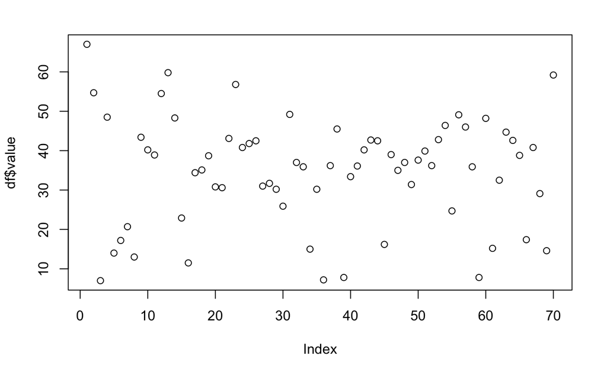

```r
plot(df$value)
```

Generating a line plot for the row values:

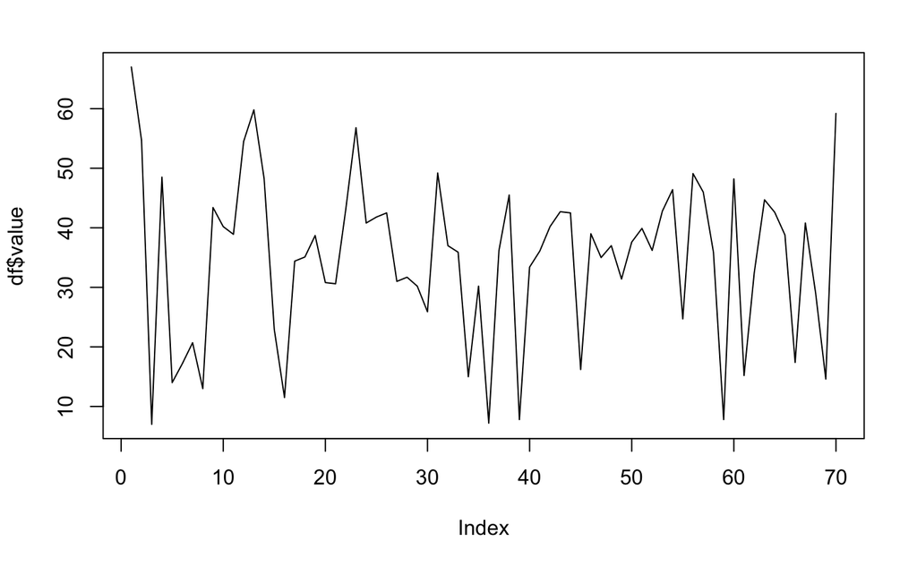

```r
plot(df$value, type='l')
```

Generating a histogram plot for the row values:

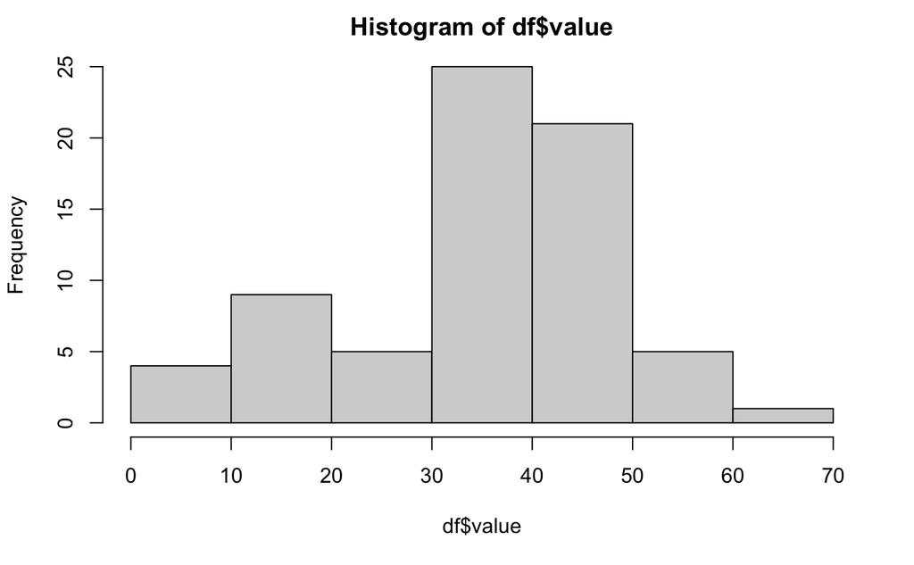

```r
hist(df$value)
```

Data frame attributes:

Inspecting the attributes of a data frame:

```r
?data.frame
```

Retrieving the column names for a data frame:

```r
colnames(df)
```

```
[1] "city"  "value"
```

Casting variables into different data types

```r
s = "Princeton"
class(s)
```

```
[1] "character"
```

For invalid values (e. g. casting `characters` to `integers`) only a `NA` is returned:

```r
as.numeric(s)
```

```
[1] NA
```

```r
s2 = "123"
as.numeric(s2)
```

```
[1] 123
```